# Algorithm to make city urban master plan

## Description

### Input data

Input - GeoJSON file with main objects, restrictions and areas for buildings The program must do next:

1. Plot boundaries – transmitted in GeoJSON format (FeatureCollection with Polygon).
2. Take into account restrictions on building density – percentage of the plot area allowed for development.
3. Take into account minimum distance between objects – for example, 10 meters between buildings.
4. Additional restrictions – presence of roads, forests, water bodies on which construction is prohibited (also transmitted in GeoJSON).

### Algorithm tasks

1. Divide the site into logical zones (e.g. residential buildings, parks, roads).
2. Place objects (buildings, roads, green areas) taking into account the specified restrictions, excluding construction in prohibited zones (roads, forests, water bodies).
3. Generate an image of the site plan.
4. Create a GeoJSON file with the coordinates of the placed objects.

```
The autoreload extension is already loaded. To reload it, use:
  %reload_ext autoreload
```

```
output\geo_data_1_output
```

```
                                            geometry            name  \
0  POLYGON ((30.3 59.92, 30.315 59.92, 30.315 59....  Зона застройки
1  POLYGON ((30.31 59.925, 30.313 59.925, 30.313 ...     Лесная зона
2          LINESTRING (30.302 59.922, 30.314 59.922)          Дорога

  restriction
0         NaN
1    no_build
2    no_build
```

Before - project coordinates to local meters system for simplifying further analyze. After analyze and design the result would be exported to original coordinate system

```
                                            geometry            name  \
0  POLYGON ((14497.807 6674490.423, 15331.646 667...  Зона застройки
1  POLYGON ((15126.921 6674970.475, 15293.664 667...     Лесная зона
2  LINESTRING (14638.3 6674697.148, 15305.331 667...          Дорога

  restriction
0         NaN
1    no_build
2    no_build
```

```
Local bounds: [   0.            0.          965.56764709 1106.81188693]
```

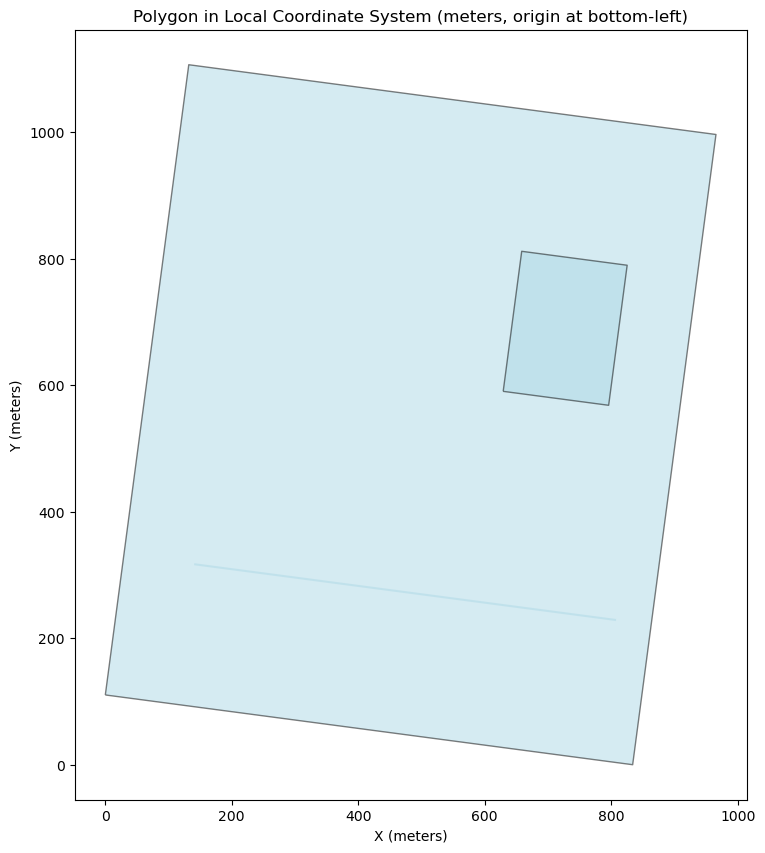

```
Back to WGS84 bounds: [30.3   59.92  30.315 59.929]
```

```
                                            geometry            name  \
0  POLYGON ((0 110.316, 833.839 0, 965.568 996.51...  Зона застройки
1  POLYGON ((629.114 590.367, 795.858 568.317, 82...     Лесная зона
2  POLYGON ((807.787 230.779, 807.98 230.744, 808...          Дорога

  restriction
0         NaN
1    no_build
2    no_build
```

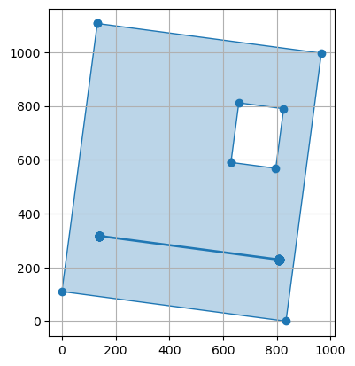

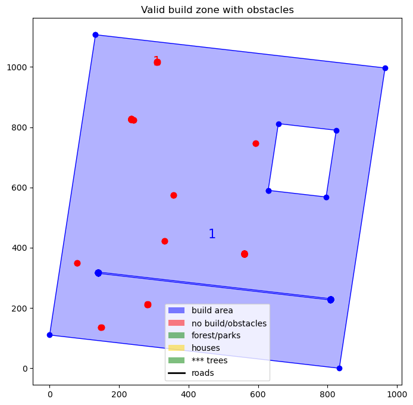

```
(<Figure size 800x800 with 1 Axes>, <Axes: >)
```

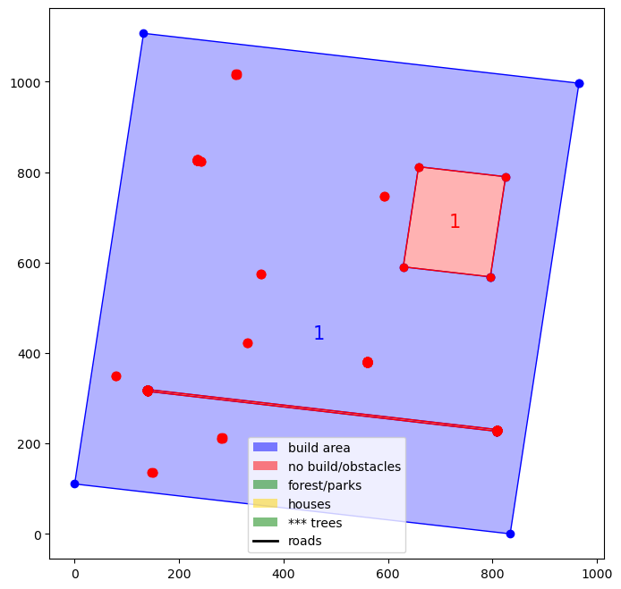

Separate territory into zones for buildings, roads and park For separation Voronoi diagram would be used

```
max_build_area:322032.64
required_radius:35.23
house_zone_area:3899.49
n_houses_max:83
```

[output not shown]

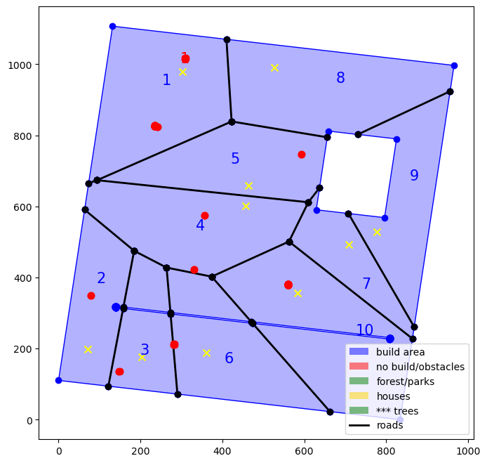

```
[[0. 0. 0. 0. 1. 1. 0. 0. 0. 1. 0. 0.]
 [0. 0. 1. 1. 1. 0. 0. 0. 0. 0. 0. 0.]
 [0. 1. 0. 0. 0. 0. 1. 0. 0. 0. 0. 0.]
 [0. 1. 0. 0. 1. 0. 0. 1. 0. 0. 0. 0.]
 [1. 1. 0. 1. 0. 1. 0. 1. 1. 0. 0. 1.]
 [1. 0. 0. 0. 1. 0. 0. 0. 1. 1. 0. 0.]
 [0. 0. 1. 0. 0. 0. 0. 0. 0. 0. 0. 1.]
 [0. 0. 0. 1. 1. 0. 0. 0. 0. 0. 0. 1.]
 [0. 0. 0. 0. 1. 1. 0. 0. 0. 0. 1. 1.]
 [1. 0. 0. 0. 0. 1. 0. 0. 0. 0. 1. 0.]
 [0. 0. 0. 0. 0. 0. 0. 0. 1. 1. 0. 0.]
 [0. 0. 0. 0. 1. 0. 1. 1. 1. 0. 0. 0.]]
[3. 3. 2. 3. 7. 4. 2. 3. 4. 3. 2. 4.]
```

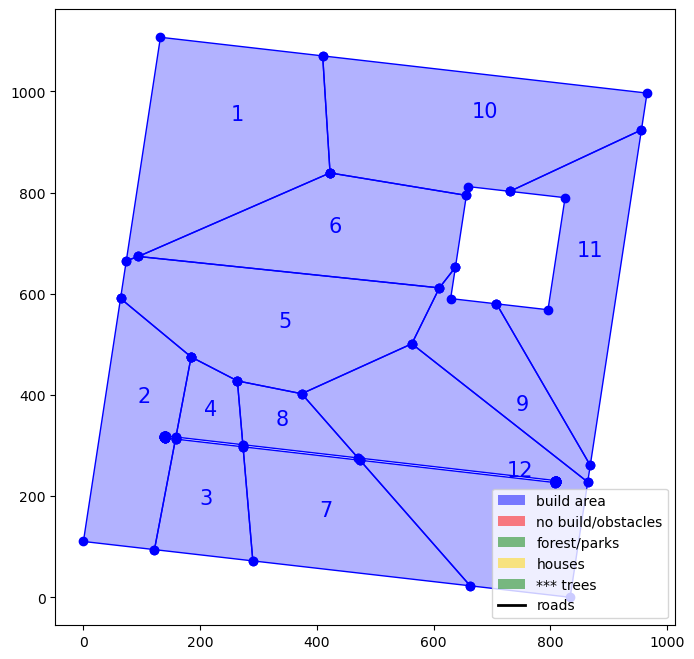

[output not shown]

```
(<Figure size 800x800 with 1 Axes>, <Axes: >)
```

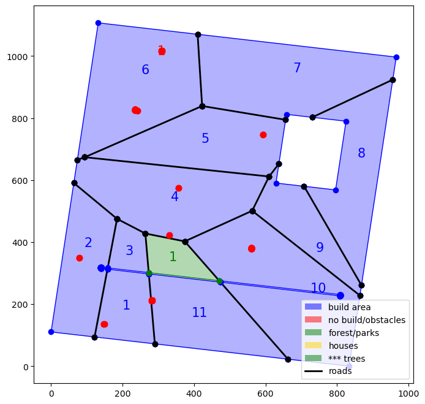

```
area for buildings except parks: 805081.5943439936,
is it enough (>322032.63773759746)?: True
```

now lest add some syntetic obstacles in the middle of the road and try to optimize the path to go around it + take into account other obstacles we had before

```
road 0: (409.89396379279367, 1070.0377610923608) - (422.5350247445023, 838.7493549684577)
road constructed in 3 parts
road 1: (422.5350247445023, 838.7493549684577) - (94.20595932659657, 673.6163099132231)
road constructed in 3 parts
road 2: (94.20595932659657, 673.6163099132231) - (73.4708517892446, 665.1443658161063)
road constructed in 2 parts
road 3: (63.59563848127262, 590.5699178681673) - (184.55691169155472, 474.98345779389456)
road constructed in 2 parts
road 4: (184.55691169155472, 474.98345779389456) - (121.7141123847911, 94.21337913964439)
road constructed in 3 parts
road 5: (184.55691169155472, 474.98345779389456) - (263.7780339415514, 427.6864476456708)
road constructed in 2 parts
road 6: (263.7780339415514, 427.6864476456708) - (290.26281307311575, 71.91456739526924)
road constructed in 4 parts
road 7: (94.20595932659657, 673.6163099132231) - (609.8138137790854, 611.5147076123104)
road constructed in 2 parts
road 8: (609.8138137790854, 611.5147076123104) - (562.61206467173, 501.0061661109906)
road constructed in 2 parts
road 9: (562.61206467173, 501.0061661109906) - (373.9481571628333, 402.300980682837)
road constructed in 2 parts
road 10: (373.9481571628333, 402.300980682837) - (263.7780339415514, 427.6864476456708)
road constructed in 2 parts
road 11: (422.5350247445023, 838.7493549684577) - (656.0872468700647, 794.2938048130346)
No path found around obstacles
road 12: (637.3120142419134, 652.3457183314292) - (609.8138137790854, 611.5147076123104)
No path found around obstacles
road 13: (373.9481571628333, 402.300980682837) - (662.6076221597741, 22.653749792337532)
road constructed in 4 parts
road 14: (707.6351616426545, 579.9833772111109) - (868.3009938494016, 260.7011004549235)
road constructed in 2 parts
road 15: (863.9469973201803, 227.76344296586996) - (562.61206467173, 501.0061661109906)
road constructed in 2 parts
road 16: (955.9472313361591, 923.7383195175283) - (730.5794045404641, 802.2688677978178)
road constructed in 2 parts
```

```
(<Figure size 800x800 with 1 Axes>, <Axes: >)
```

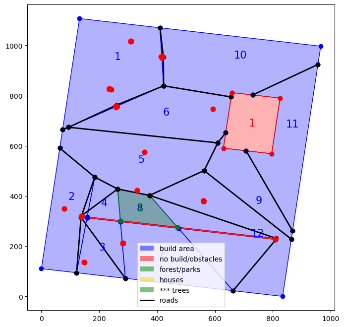

```
                                             geometry  \
0   POLYGON ((0 110.316, 833.839 0, 965.568 996.51...
1   POLYGON ((629.114 590.367, 795.858 568.317, 82...
2   POLYGON ((807.787 230.779, 807.98 230.744, 808...
0   MULTIPOLYGON (((561.855 379.677, 561.848 379.5...
0   POLYGON ((422.535 838.749, 94.206 673.616, 73....
1   POLYGON ((184.557 474.983, 158.431 316.685, 14...
2   POLYGON ((157.779 312.736, 273.475 297.43, 290...
3   POLYGON ((184.557 474.983, 263.778 427.686, 27...
4   POLYGON ((63.596 590.57, 73.471 665.144, 94.20...
5   POLYGON ((422.535 838.749, 656.087 794.294, 63...
6   POLYGON ((273.475 297.43, 473.839 270.923, 662...
7   POLYGON ((263.778 427.686, 373.948 402.301, 47...
8   POLYGON ((637.312 652.346, 629.114 590.367, 70...
9   POLYGON ((730.579 802.269, 658.405 811.814, 65...
```

[output cut: 60 more lines]

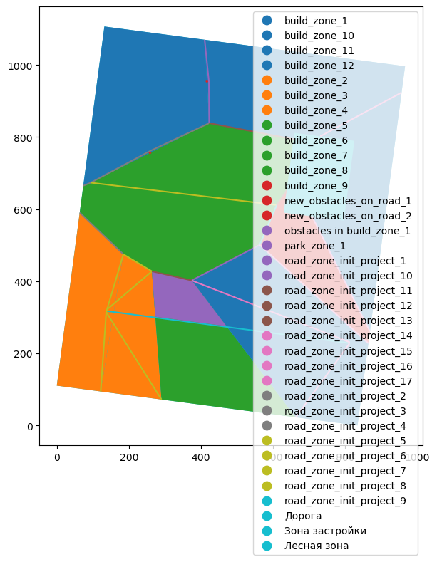

# Place objects into map - buildings, roads, green zones

taking into account restrictions

```
(<Figure size 800x800 with 1 Axes>, <Axes: >)
```

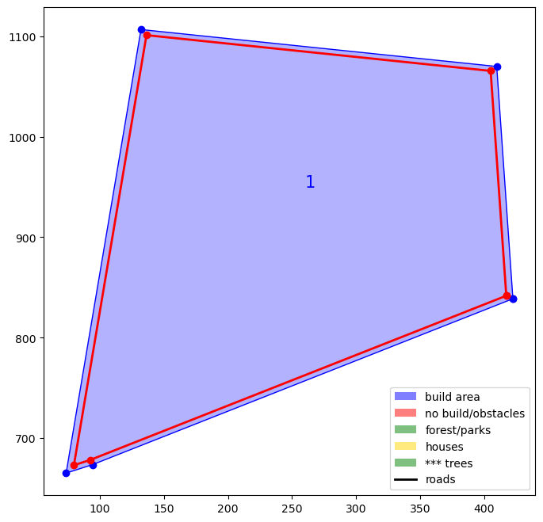

```
zone 0
poly_area:31735.06
house radius:25.23
poly_build_area:12694.02
center_zone_area:3899.49
estimated number of centers: 4
estimated number of houses: 7
number of generated centers on grid: 2
Could only place 2 of 4 centers due to space/restrictions
number of generated centers on grid: 43
select that are far from restrictions

zone 1
poly_area:56322.64
house radius:25.23
poly_build_area:22529.06
center_zone_area:3899.49
estimated number of centers: 6
estimated number of houses: 12
number of generated centers on grid: 10
select that are far from restrictions
number of generated centers on grid: 59
select that are far from restrictions

zone 2
poly_area:14055.86
house radius:25.23
poly_build_area:5622.34
center_zone_area:3899.49
estimated number of centers: 2
estimated number of houses: 3
Could only place 0 of 2 centers due to space/restrictions
number of generated centers on grid: 25
select that are far from restrictions

zone 3
poly_area:94004.01
house radius:25.23
poly_build_area:37601.60
center_zone_area:3899.49
```

[output cut: 78 more lines]

```

zone 10
poly_area:63941.71
house radius:25.23
poly_build_area:25576.68
center_zone_area:3899.49
estimated number of centers: 7
estimated number of houses: 13
number of generated centers on grid: 14
select that are far from restrictions
number of generated centers on grid: 76
select that are far from restrictions
Warning: Requested 18087 centers, but max possible ~47
number of generated centers on grid: 38
Could only place 38 of 18087 centers due to space/restrictions
```

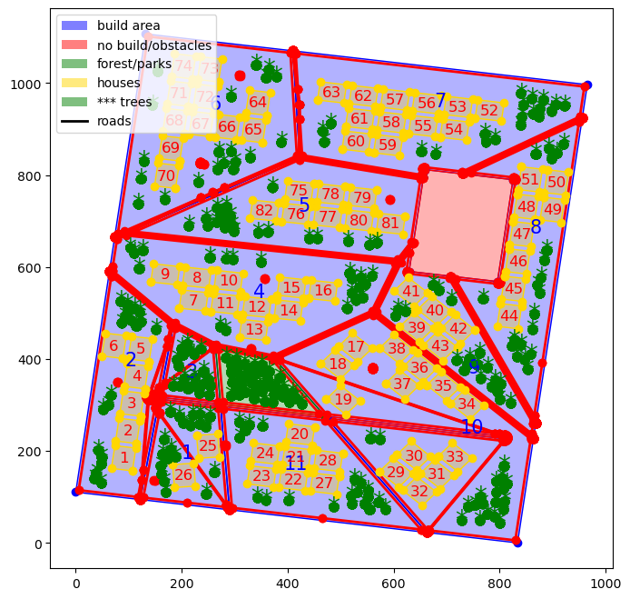

# Save and export results

```
Map saved to output\geo_data_1_output.png
```

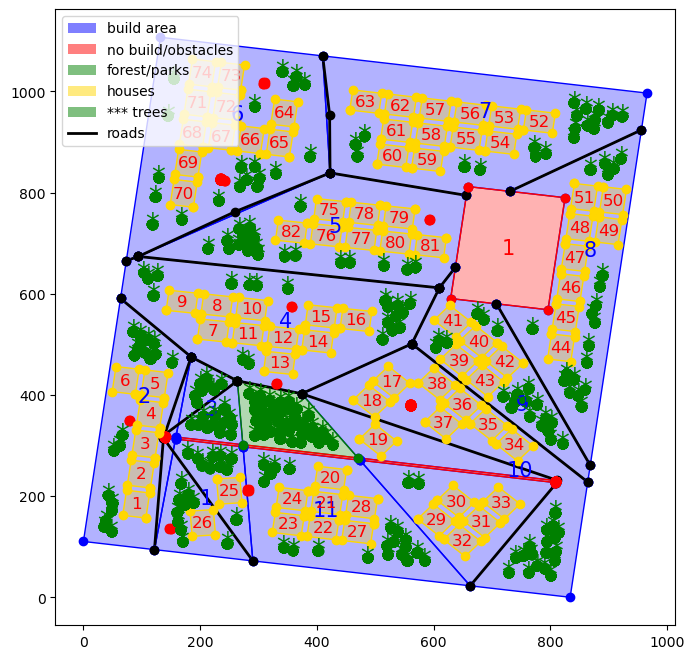

all coordinates are converted from local back to EPSG

```
                                             geometry  \
0   POLYGON ((30.3 59.92, 30.315 59.92, 30.315 59....
1   POLYGON ((30.31 59.925, 30.313 59.925, 30.313 ...
2   POLYGON ((30.314 59.92202, 30.314 59.92202, 30...
0   MULTIPOLYGON (((30.3093 59.92305, 30.3093 59.9...
0   POLYGON ((30.30577 59.92696, 30.30035 59.92511...
..                                                ...
33  POLYGON ((30.30497 59.92224, 30.30497 59.92224...
34  POLYGON ((30.30674 59.9224, 30.30674 59.9224, ...
35  POLYGON ((30.30561 59.92275, 30.30561 59.92275...
36  POLYGON ((30.30516 59.92274, 30.30516 59.92273...
37  POLYGON ((30.30492 59.92262, 30.30492 59.92262...

                         name restriction
0              Зона застройки         NaN
1                 Лесная зона    no_build
2                      Дорога    no_build
0   obstacles in build_zone_1    no_build
0                build_zone_1    build_ok
..                        ...         ...
33                   trees_34    build_ok
34                   trees_35    build_ok
35                   trees_36    build_ok
36                   trees_37    build_ok
37                   trees_38    build_ok

[156 rows x 3 columns]
Exported to output\geo_data_1_output.json
```

```
Report saved to output\geo_data_1_output.html
```